# Vaccine Supply Chain Optimization Problem for Covid19 Pandemic Crisis

This problem represents the optimal planning of COVID-19 vaccine supply chain between Vaccine Storage Units and Vaccination Centers. The goal of the problem is to minimize the total costs, including storage, transportation costs and extra transportation costs due to different supply conditions of each vaccine.

Vaccine Supply Chain

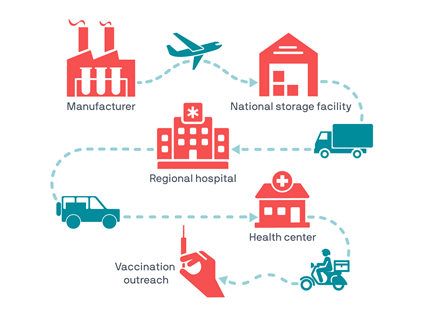

As it can be seen in the above visual, Vaccine Supply Chain is very huge and it is quite important. However, in this optimization problem, only the supply chain between vaccine storages and local vaccination centers has been illustrated simply.

## Problem Description

First, vaccines that are supplied from factories arrive to the Vaccine Stroge Units(VSU). After arriving to the VSU, according to the demand of each Vaccine Center (VC), vaccines are transferred to the VCs. However, there are vaccines that remain after this process due to the stock and demand of each vaccine. In this case, there are holding costs for both VSUs and VCs to store the vaccines. All vaccine types' stocks at Vaccine Stroge Units (VSU), their demands at Vaccination Centers (VC), and their extra costs due to their stroge requirements are provided.

In the problem, three vaccines with different characteristics are studied. In particular, the vaccines of AstraZeneca, Moderna and Pfizer are considered. Each vaccine type has different holding requirements, deep freezers (−70 °C) are required for Pfizer and regular freezers (−20 °C) for Moderna vaccines, while simple refrigeration is enough for AstraZeneca. As each vaccine has different requirements for supplying, extra supply chain cost for each vaccine was determined. Pfizer has the highest cost as its transportation expenses are higher, and Moderna has the second highest price while AstraZeneca has the least price. Moreover, the capacity of holding the vaccines at both VSUs and VCs was determined randomly by generating the random number of refrigerations for each type of vaccine. Then these numbers are multiplied by 100, because it has been assumed that each freezer could keep 100 units. In this problem, each VSU and VC have each type of refrigeration technologies. Therefore, there is no zero capacity. However, as the problem is continous linear problem, this situation also can be examined when the associated data provided.

## Model Sets and Parameters

In this problem, there are 3 types of vaccines, five Vaccine Stroge Units and 13 Vaccination Centers, each with a known demand for each vaccine. Vaccination centers' demand can be supplied from five VSUs. There are known costs associated with transporting each type of vaccine, from a VSU to a VC.

-Shipping distance between VSUs and VCs are given in the following table:

| Distance between VSUs and VCs | VC1 | VC2 | VC3 | VC4 | VC5 | VC6 | VC7 | VC8 | VC9 | VC10 | VC11 | VC12 | VC13 |
| --- | --- | --- | --- | --- | --- | --- | --- | --- | --- | --- | --- | --- | --- |
| VSU1 | 3.29 | 3.32 | 3.13 | 3.16 | 3.14 | 3.58 | 5.58 | 8.72 | 9.13 | 3.95 | 7.79 | 7.11 | 4.27 |
| VSU2 | 4.13 | 5.69 | 8.67 | 7.9 | 7.71 | 5.47 | 5.72 | 6.32 | 4.28 | 8.31 | 9.55 | 3.25 | 1.44 |
| VSU3 | 2.49 | 6.80 | 2.76 | 8.59 | 4.72 | 2.38 | 7.50 | 4.34 | 7.19 | 5.36 | 5.16 | 8.37 | 8.81 |
| VSU4 | 6.36 | 4.65 | 8.22 | 7.16 | 8.55 | 2.47 | 7.69 | 2.45 | 6.77 | 1.03 | 5.33 | 1.31 | 6.25 |
| VSU5 | 3.21 | 3.43 | 6.13 | 2.39 | 8.74 | 6.68 | 4.00 | 4.19 | 8.95 | 7.29 | 6.16 | 4.93 | 8.33 |

-Stocks for each Vaccine type at each VSU:

| Vaccine Stroge Units (in vials) | VSU1 | VSU2 | VSU3 | VSU4 | VSU5 |
| --- | --- | --- | --- | --- | --- |
| Pfizer | 1850 | 2450 | 1735 | 2500 | 1400 |
| Moderna | 1600 | 2400 | 1200 | 2100 | 3500 |
| AstraZeneca | 4000 | 3800 | 2800 | 4100 | 3800 |

-Stocks capacity after shipping to VCs for each Vaccine type at each VSU:

| Vaccine Stroge Capacity Units (in vials) | VSU1 | VSU2 | VSU3 | VSU4 | VSU5 |
| --- | --- | --- | --- | --- | --- |
| Pfizer | 1700 | 4500 | 2200 | 3100 | 1100 |
| Moderna | 2700 | 2100 | 1800 | 2000 | 3800 |
| AstraZeneca | 4700 | 4100 | 2100 | 4200 | 3800 |
| Holding Cost(€) | 7.0 | 5.0 | 7.5 | 7.0 | 4.0 |

-Each vaccine can be shipped from a Vaccine Storage Unit to a set of vaccination centers. The flow amount is depending on each Vaccination center demands.

[output not shown]

-Each vaccination center has a maximum capacity of storing the vaccines. Vaccine centers can hold the vaccines more than demand if the capacity constarints is provided, therefore, vaccines can be kept at VCs until they are used for the people.

| Vaccine Capacity | VC1 | VC2 | VC3 | VC4 | VC5 | VC6 | VC7 | VC8 | VC9 | VC10 | VC11 | VC12 | VC13 |
| --- | --- | --- | --- | --- | --- | --- | --- | --- | --- | --- | --- | --- | --- |
| Pfizer | 1400 | 800 | 500 | 600 | 955 | 975 | 445 | 750 | 475 | 635 | 930 | 1300 | 740 |
| Moderna | 1000 | 890 | 510 | 1050 | 950 | 750 | 500 | 1105 | 840 | 830 | 500 | 980 | 980 |
| AstraZeneca | 2600 | 1700 | 1200 | 950 | 1400 | 2400 | 1200 | 2000 | 1800 | 1300 | 800 | 2400 | 600 |
| Holding Cost(€) | 3.5 | 8.0 | 9.7 | 6.5 | 4.5 | 5.0 | 9.0 | 8.0 | 7.2 | 8.4 | 4.2 | 3.6 | 9.5 |

-Extra Shipping cost (Extra shipping cost*Amount of vaccine units) of each vaccine (in units) from the VSUs to the VCs.

- Extra shipping cost was determined according to each vaccine types' supply chain requirement expenses. The highest price was defined for Pfizer because of its cold supply chain requirements, also AstraZeneca is the least one because this type of vaccine does not require a deep freezer. Moreover, Moderna also requires -20°C, therefore the second highest price was determined.

| Extra Shipping Cost | Cost (in euros per unit) |
| --- | --- |
| Pfizer | x 6.5 |
| Moderna | x 4.75 |
| AstraZeneca | x 2.25 |

The question to be answered is how to satisfy the demand of the each Vaccination Center while minimizing the total cost.

# a) Model Formulation

### Sets and Indices

$f \in \text{Vaccine Storage Units}=\{\text{VSU1}, \text{VSU2}, \text{VSU3},\text{VSU4},\text{VSU5}\}$

$d \in \text{Vaccine Centers}=\{\text{VC 1}, \text{VC 2}, \text{VC 3}, \text{VC 4}, \text{VC 5}, \text{VC 6}, \text{VC 7}, \text{VC 8}, \text{VC 9}, \text{VC 10}, \text{VC 11}, \text{VC 12}, \text{VC 13}\}$

$v \in \text{Vaccines}=\{\text{Pfizer}, \text{Moderna}, \text{AstraZeneca}\}$

### Parameters

$\text{Tc} \in \mathbb{R}^+$: Transportation cost per distance units.

$\text{Hc}_{f} \in \mathbb{R}^+$: Holding cost at VSUs in vials (€).

$\text{Hc}_{d} \in \mathbb{R}^+$: Holding cost at VCs in vials (€).

$\text{dist}_{f,d} \in \mathbb{R}^+$: Distance of shipping units from VSU $f$ to vaccination center $d$.

$\text{extracost}_{v} \in \mathbb{R}^+$: Extra shipping cost for each type of vaccine $v$.

$\text{stock}_{v,f} \in \mathbb{R}^+$: Stock of each vaccine $v$ at VSUs $f$ that distributed from factories (in units).

$\text{storage_cap}_{v,f} \in \mathbb{R}^+$: Maximum possible stroge of vaccine $v$ at VSU $f$ (in units).

$\text{cap}_{v,d} \in \mathbb{R}^+$: Maximum possible storage for each vaccine $v$ at vaccine center $d$ (in units).

$\text{demand}_{v,d} \in \mathbb{R}^+$: Demand for each vaccine $v$ at each vaccine center $d$ (in units).

### Decision Variables

$\text{X}_{v,f,d} \in \mathbb{N}^+$: Quantity of vaccines $v$ (in units) that is shipped from source $f$ to destionation $d$.

### Objective Function

- **Cost**: Minimize total costs.

\begin{equation} \text{Minimize} \quad Z = \sum_{v=1}^{V}\sum_{f=1}^{F}\sum_{d=1}^{D}extracost_{v}*X_{v,f,d}+ \sum_{f=1}^{F}\sum_{d=1}^{D}*Tc*dist_{f,d}+ \sum_{f=1}^{F}\sum_{v=1}^{V}\sum_{d=1}^{D}Hc_{f}*(stock_{v,f}-X_{v,f,d})+ \sum_{d=1}^{D}\sum_{v=1}^{V}\sum_{f=1}^{F}Hc_{d}*(X_{v,f,d}-demand_{v,d})\\ \end{equation}

### Constraints

- **Shipped Stock Limit**: At least 80% of the stock of each type of vaccine at each VSU must be shipped.

\begin{equation} \sum_{f=1}^{F}\sum_{v=1}^{V}\sum_{d=1}^{D}(stock_{v,f}-X_{v,f,d}) \geq \sum_{f=1}^{F}\sum_{v=1}^{V}stock{v,f}*0.80 \quad \forall f,v \in \text{Vaccines, Vaccine Storage Units} \end{equation}

- **Stock limit**: At least 2 vials for each type of vaccine must be kept in the storage.

\begin{equation} \sum_{f=1}^{F}\sum_{v=1}^{V}\sum_{d=1}^{D}(stock_{v,f}-X_{v,f,d}) \geq 2 \quad \forall f,v \in \text{Vaccines, Vaccine Storage Units} \end{equation}

- **VSU output**: After transforming the vaccines from a VSU, the remaining stocks must respect to the maximum storage capacity.

\begin{equation} \sum_{f=1}^{F}\sum_{d=1}^{D}\sum_{v=1}^{V}(stock_{v,f}-X_{v,f,d}) \leq \sum_{f=1}^{F}\sum_{v=1}^{V}storagecap_{v,f} \quad \forall v,f \in \text{Vaccines, Vaccine Storage Units} \end{equation}

- **Vaccine centers demand**: The amount of vaccine shipped from VSU to VC must be greater than or equal to the vaccine demand at VCs.

\begin{equation} \sum_{d=1}^{D}\sum_{v=1}^{V}\sum_{f=1}^{F}X_{v,f,d} \geq \sum_{d=1}^{D}\sum_{v=1}^{V}demand_{v,d} \quad \forall v,d \in \text{Vaccines, Vaccination Centers} \end{equation}

- **Vaccine centers storage capacity limit**: Flow of vaccines from a VSU to a VC must respect maximum storing capacity.

\begin{equation} \sum_{d=1}^{D}\sum_{v=1}^{V}\sum_{f=1}^{F}X_{v,f,d} \leq \sum_{d=1}^{D}\sum_{v=1}^{V}cap_{v,d} \quad \forall v,d \in \text{Vaccines, Vaccination Centers} \end{equation}

# b) Solving the Model in Pyomo

Data of the Vaccine Model

```python
import numpy as np

F =  list(range(1,6));
D =  list(range(1,14));
V =  list(range(1,4));

Tc = 5;

dist = np.array([[3.29 ,3.32 ,3.13 ,3.16 ,3.14 ,3.58 ,5.58  ,8.72 , 9.13 , 3.95 ,7.79 ,7.11 ,4.27   ]  ,
                [4.13 ,5.69 ,8.67 ,7.9  ,7.71 ,5.47 ,5.72  ,6.32 , 4.28 , 8.31 ,9.55 ,3.25 ,1.44    ] ,
                [2.49 ,6.80 ,2.76 ,8.59 ,4.72 ,2.38 ,7.50  ,4.34 , 7.19 , 5.36 ,5.16 ,8.37 ,8.81    ] ,
                [6.36 ,4.65 ,8.22 ,7.16 ,8.55 ,2.47 ,7.69  ,2.45 , 6.77 , 1.03 ,5.33 ,1.31 ,6.25    ] ,
                [3.21 ,3.43 ,6.13 ,2.39 ,8.74 ,6.68 ,4.00  ,4.19 , 8.95 , 7.29 ,6.16 ,4.93 ,8.33    ] ]);

extracost = np.array([ 6.5,4.75,2.25 ]);

Hc_VSU = np.array([7.0, 5.0, 7.5, 7.0, 4.0]);

Hc_VC = np.array([3.5,8.0,9.7,6.5,4.5,5.0,9.0,8.0,7.2,8.4,4.2,3.6,9.5]);

stock = np.array([[1850 ,2450 ,1735 ,2500 ,1400],
                  [1600 ,2400 ,1200 ,2100 ,3500],
                  [4000 ,3800 ,2800 ,4100 ,3800]]);


storage_cap = np.array([[1700, 4500, 2200, 3100, 1100],
                       [2700, 2100, 1800, 2000, 3800],
                       [4700, 4100, 2100, 4200, 3800]]);

demand =np.array([[1100 ,750  ,375  ,580  ,950  ,970  ,440  ,745  ,465  ,630  ,920  ,1260 ,730 ],
                  [960  ,885  ,505  ,1040 ,920  ,720  ,460  ,1100 ,830  ,820  ,495  ,970  ,960 ],
                  [2430 ,1500 ,990  ,870  ,1140 ,2060 ,1010 ,1620 ,1390 ,910  ,420  ,1890 ,510 ]]);



cap = np.array([[1400 ,800  ,500  ,600  ,955   ,975  ,445  ,750  ,475 ,635 ,930  ,1300 ,740],
                [1000 ,890  ,510  ,1050 ,950   ,750  ,500  ,1105 ,840 ,830 ,500  ,980  ,980],
                [2600 ,1700 ,1200 ,950  ,1400  ,2400 ,1200 ,2000 ,1800,1300,800  ,2400 ,600]]);
```

Vaccine model sets, parameters, variables, objective function and constraints:

```python
from pyomo.environ import *
opt = SolverFactory('glpk')

model = ConcreteModel(name="Vaccine Model")

#Sets#
# Vaccine Stroge Units
model.F = Set(initialize=F)
# Vaccine Centers
model.D = Set(initialize=D)
# Vaccine Types
model.V = Set(initialize=V)


# decision variables
model.X = Var(model.V,model.F,model.D, domain= NonNegativeReals)

# Minimize the cost
def cost_rule(model):
	return sum(sum(sum(extracost[v-1]*model.X[v,f,d] for d in model.D) for f in model.F) for v in model.V)+\
sum(sum(Tc*dist[f-1,d-1] for d in model.V) for f in model.F)+\
sum(sum(sum(Hc_VSU[f-1]*(stock[v-1,f-1] - model.X[v,f,d]) for d in model.D) for v in model.V) for f in model.F)+\
sum(sum(sum(Hc_VC[d-1]*(model.X[v,f,d] - demand[v-1,d-1]) for f in model.F) for v in model.V) for d in model.D)
model.Obj = Objective(rule=cost_rule, sense=minimize)


#Constraints

#at least 80% of the stock must be shipped.
def flow(model,v,f):
    return sum(model.X[v,f,d] for d in model.D) >= stock[v-1,f-1]*0.80
model.flow_const = Constraint(model.V,model.F, rule=flow)

#At least 2 vials for each type of vaccine must be kept in the storage.
def stock_flow_limit(model,v,f):
    return stock[v-1,f-1]-sum(model.X[v,f,d] for d in model.D) >= 2
model.stock_const = Constraint(model.V,model.F, rule=stock_flow_limit)

#After transforming the vaccines from a VSU, the remaining stocks must respect to the maximum storage capacity.
def storage_output(model,v, f):
    return stock[v-1,f-1] - sum(model.X[v,f,d] for d in model.D) <= storage_cap[v-1,f-1]
model.storage_const = Constraint(model.V,model.F, rule=storage_output)

#The amount of vaccine shipped from VSU to VC must be greater than or equal to the vaccine demand at VCs.
def vc_demand(model,v,d):
    return sum(model.X[v,f,d] for f in model.F) >= demand[v-1,d-1]
model.demand_const = Constraint(model.V, model.D, rule=vc_demand)

#Flow of vaccines from a VSU to a VC must respect maximum storing capacity.
def vc_capacity(model,v,d):
    return sum(model.X[v,f,d] for f in model.F) <= cap[v-1,d-1]
model.cap_const = Constraint(model.V, model.D, rule=vc_capacity)

#load dual information
model.dual = Suffix(direction=Suffix.IMPORT)

#solve
results = opt.solve(model, tee=True)

#model.Obj()
model.display()
#model.dual.display()
```

```
GLPSOL--GLPK LP/MIP Solver 5.0
Parameter(s) specified in the command line:
 --write C:\Users\belce\AppData\Local\Temp\tmp7w9wr2e7.glpk.raw --wglp C:\Users\belce\AppData\Local\Temp\tmpsrscusg2.glpk.glp
 --cpxlp C:\Users\belce\AppData\Local\Temp\tmp87vmk3ju.pyomo.lp
Reading problem data from 'C:\Users\belce\AppData\Local\Temp\tmp87vmk3ju.pyomo.lp'...
124 rows, 196 columns, 976 non-zeros
1747 lines were read
Writing problem data to 'C:\Users\belce\AppData\Local\Temp\tmpsrscusg2.glpk.glp'...
1619 lines were written
GLPK Simplex Optimizer 5.0
124 rows, 196 columns, 976 non-zeros
Preprocessing...
113 rows, 195 columns, 845 non-zeros
Scaling...
 A: min|aij| =  1.000e+00  max|aij| =  1.000e+00  ratio =  1.000e+00
Problem data seem to be well scaled
Constructing initial basis...
Size of triangular part is 113
      0: obj =   1.869228900e+06 inf =   7.026e+04 (59)
     71: obj =   2.034273650e+06 inf =   0.000e+00 (0)
*    78: obj =   2.031703550e+06 inf =   0.000e+00 (0)
OPTIMAL LP SOLUTION FOUND
Time used:   0.0 secs
Memory used: 0.3 Mb (304467 bytes)
Writing basic solution to 'C:\Users\belce\AppData\Local\Temp\tmp7w9wr2e7.glpk.raw'...
329 lines were written
Model Vaccine Model

  Variables:
    X : Size=195, Index=X_index
        Key        : Lower : Value  : Upper : Fixed : Stale : Domain
         (1, 1, 1) :     0 :  972.0 :  None : False : False : NonNegativeReals
         (1, 1, 2) :     0 :    0.0 :  None : False : False : NonNegativeReals
         (1, 1, 3) :     0 :    0.0 :  None : False : False : NonNegativeReals
         (1, 1, 4) :     0 :    0.0 :  None : False : False : NonNegativeReals
         (1, 1, 5) :     0 :    0.0 :  None : False : False : NonNegativeReals
         (1, 1, 6) :     0 :    0.0 :  None : False : False : NonNegativeReals
         (1, 1, 7) :     0 :    0.0 :  None : False : False : NonNegativeReals
         (1, 1, 8) :     0 :    0.0 :  None : False : False : NonNegativeReals
         (1, 1, 9) :     0 :    0.0 :  None : False : False : NonNegativeReals
```

[output cut: 311 more lines]

```
        (2, 12) :  None :  970.0 :  980.0
        (2, 13) :  None :  960.0 :  980.0
         (3, 1) :  None : 2600.0 : 2600.0
         (3, 2) :  None : 1500.0 : 1700.0
         (3, 3) :  None :  990.0 : 1200.0
         (3, 4) :  None :  870.0 :  950.0
         (3, 5) :  None : 1140.0 : 1400.0
         (3, 6) :  None : 2060.0 : 2400.0
         (3, 7) :  None : 1010.0 : 1200.0
         (3, 8) :  None : 1620.0 : 2000.0
         (3, 9) :  None : 1390.0 : 1800.0
        (3, 10) :  None :  910.0 : 1300.0
        (3, 11) :  None :  420.0 :  800.0
        (3, 12) :  None : 1954.0 : 2400.0
        (3, 13) :  None :  510.0 :  600.0
```

# c) Computing Sensitivities associated with each constraint

```python
#check dual information

dual_flow = np.zeros((len(V),len(F)))
for v in range(0,len(V)):
    for f in range(0,len(F)):
        dual_flow[v][f]=model.dual[model.flow_const[v+1,f+1]]

dual_stock = np.zeros((len(V),len(F)))
for v in range(0,len(V)):
    for f in range(0,len(F)):
        dual_stock[v][f]=model.dual[model.stock_const[v+1,f+1]]

dual_storage = np.zeros((len(V),len(F)))
for v in range(0,len(V)):
    for f in range(0,len(F)):
        dual_storage[v][f]=model.dual[model.storage_const[v+1,f+1]]

dual_cap = np.zeros((len(V),len(D)))
for v in range(0,len(V)):
    for d in range(0,len(D)):
        dual_cap[v][d]=model.dual[model.cap_const[v+1,d+1]]


dual_demand=np.zeros((len(V),len(D)))
for v in range(0,len(V)):
    for d in range(0,len(D)):
        dual_demand[v][d]=model.dual[model.demand_const[v+1,d+1]]


print('sensitivity min flow of vaccine from VSUs to VCs= \n' ,dual_flow)
print('sensitivity min amount of vials have to be kept at VSUs= \n' ,dual_stock)
print('sensitivity max capacity of VSUs= \n' ,dual_storage)
print('sensitivity max capacity of VCs= \n' ,dual_cap)
print('sensitivity minimum demand of VCs= \n' ,dual_demand)
```

```
sensitivity min flow of vaccine from VSUs to VCs=
 [[0.   0.   0.   0.   0.  ]
 [0.   0.   0.   0.   0.  ]
 [0.   0.85 0.   0.   1.85]]
sensitivity min amount of vials have to be kept at VSUs=
 [[3.   1.   3.5  3.   0.  ]
 [3.   1.   3.5  3.   0.  ]
 [1.15 0.   1.65 1.15 0.  ]]
sensitivity max capacity of VSUs=
 [[0. 0. 0. 0. 0.]
 [0. 0. 0. 0. 0.]
 [0. 0. 0. 0. 0.]]
sensitivity max capacity of VCs=
 [[ 0.   0.   0.   0.   0.   0.   0.   0.   0.   0.   0.   0.   0. ]
 [ 0.   0.   0.   0.   0.   0.   0.   0.   0.   0.   0.   0.   0. ]
 [-0.1  0.   0.   0.   0.   0.   0.   0.   0.   0.   0.   0.   0. ]]
sensitivity minimum demand of VCs=
 [[ 6.   10.5  12.2   9.    7.    7.5  11.5  10.5   9.7  10.9   6.7   6.1
  12.  ]
 [ 4.25  8.75 10.45  7.25  5.25  5.75  9.75  8.75  7.95  9.15  4.95  4.35
  10.25]
 [ 0.    4.4   6.1   2.9   0.9   1.4   5.4   4.4   3.6   4.8   0.6   0.
   5.9 ]]
```

## Interpretation of the sensitivity analysis

Thanks to the sensitivity analysis, the most important constraints of the model can be determined. Each active constraint has an associated 'shadow price' as shown in the above sensitivity results of each constraint. For inequality constraints in a minimization problem, a positive optimal dual value in ">=" constraint is active, and a negative optimal dual value indicates that "<=" inequality constraint is active ´n the solution.

### Sensitivity Analysis Results:

# d) Generating Integer Optimization Problem from the Initial Optimization Model

```python
## DATA
import numpy as np

#sets
F =  list(range(1,6));
D =  list(range(1,14));
V =  list(range(1,4));

#parameters
Tc = 5;

dist = np.array([[3.29 ,3.32 ,3.13 ,3.16 ,3.14 ,3.58 ,5.58  ,8.72 , 9.13 , 3.95 ,7.79 ,7.11 ,4.27   ]  ,
                [4.13 ,5.69 ,8.67 ,7.9  ,7.71 ,5.47 ,5.72  ,6.32 , 4.28 , 8.31 ,9.55 ,3.25 ,1.44    ] ,
                [2.49 ,6.80 ,2.76 ,8.59 ,4.72 ,2.38 ,7.50  ,4.34 , 7.19 , 5.36 ,5.16 ,8.37 ,8.81    ] ,
                [6.36 ,4.65 ,8.22 ,7.16 ,8.55 ,2.47 ,7.69  ,2.45 , 6.77 , 1.03 ,5.33 ,1.31 ,6.25    ] ,
                [3.21 ,3.43 ,6.13 ,2.39 ,8.74 ,6.68 ,4.00  ,4.19 , 8.95 , 7.29 ,6.16 ,4.93 ,8.33    ] ]);

extracost = np.array([ 6.5,4.75,2.25 ]);

Hc_VSU = np.array([7.0, 5.0, 7.5, 7.0, 4.0]);

Hc_VC = np.array([3.5,8.0,9.7,6.5,4.5,5.0,9.0,8.0,7.2,8.4,4.2,3.6,9.5]);

stock = np.array([[1850 ,2450 ,1735 ,2500 ,1400],
                  [1600 ,2400 ,1200 ,2100 ,3500],
                  [4000 ,3800 ,2800 ,4100 ,3800]]);


#Storage capacity is determined by number of required diffrenet type freezers.
## *100 for each vials
storage_cap = np.array([[1700, 4500, 2200, 3100, 1100],
                       [2700, 2100, 1800, 2000, 3800],
                       [4700, 4100, 2100, 4200, 3800]]);

demand =np.array([[1100 ,750  ,375  ,580  ,950  ,970  ,440  ,745  ,465  ,630  ,920  ,1260 ,730 ],
                  [960  ,885  ,505  ,1040 ,920  ,720  ,460  ,1100 ,830  ,820  ,495  ,970  ,960 ],
                  [2430 ,1500 ,990  ,870  ,1140 ,2060 ,1010 ,1620 ,1390 ,910  ,420  ,1890 ,510 ]]);



cap = np.array([[1400 ,800  ,500  ,600  ,955   ,975  ,445  ,750  ,475 ,635 ,930  ,1300 ,740],
                [1000 ,890  ,510  ,1050 ,950   ,750  ,500  ,1105 ,840 ,830 ,500  ,980  ,980],
                [2600 ,1700 ,1200 ,950  ,1400  ,2400 ,1200 ,2000 ,1800,1300,800  ,2400 ,600]]);

## NEW PARAMETER!! ##

#risk factor to prioritize the destination - less values are more important, because of using it in the minimization.
risk = np.array([1,3,6,5,1,2,5,1,7,4,5,8,2]);
```

```python
## MODEL
from pyomo.environ import *
opt = SolverFactory('glpk')

model = ConcreteModel(name="Vaccine Integer Model")

#Sets#
# Vaccine Storage Units
model.F = Set(initialize=F)
# Vaccination Centers
model.D = Set(initialize=D)
# Vaccine Types
model.V = Set(initialize=V)

# decision variables
model.X = Var(model.V,model.F,model.D, domain= NonNegativeIntegers)
model.Y = Var(model.F,model.D ,domain= Binary) ## Binary variable

# Minimize the extra cost of each vaccine, transportation cost from f to d, holding cost at VSU and VC,
# and finally minimize the risk factor in order to prioritize the destinations that have less value. (less value because of prioritizing it!)

def cost_rule(model):
	return sum(sum(sum(extracost[v-1]*model.X[v,f,d] for d in model.D) for f in model.F) for v in model.V)+\
sum(sum(Tc*dist[f-1,d-1]*model.Y[f,d] for d in model.V) for f in model.F)+\
sum(sum(sum(Hc_VSU[f-1]*(stock[v-1,f-1] - model.X[v,f,d]) for d in model.D) for v in model.V) for f in model.F)+\
sum(sum(sum(Hc_VC[d-1]*(model.X[v,f,d] - demand[v-1,d-1]) for f in model.F) for v in model.V) for d in model.D)+\
sum(sum(risk[d-1]*model.Y[f,d] for f in model.F) for d in model.D)
model.Obj = Objective(rule=cost_rule, sense=minimize)


#Constraints
def flow(model,v,f):
    return sum(model.X[v,f,d] for d in model.D) >= stock[v-1,f-1]*0.80 #at least 5 vials from each storage..
model.flow_const = Constraint(model.V,model.F, rule=flow)

def stock_flow_limit(model, v,f):
    return stock[v-1,f-1]-sum(model.X[v,f,d] for d in model.D) >= 2
model.stock_const = Constraint(model.V,model.F, rule=stock_flow_limit)

def storage_output(model,v, f):
    return stock[v-1,f-1] - sum(model.X[v,f,d] for d in model.D) <= storage_cap[v-1,f-1]
model.storage_const = Constraint(model.V,model.F, rule=storage_output)

def vc_demand(model,v,d):
    return sum(model.X[v,f,d] for f in model.F) >= demand[v-1,d-1]
model.demand_const = Constraint(model.V, model.D, rule=vc_demand)

def vc_capacity(model,v,d):
    return sum(model.X[v,f,d] for f in model.F) <= cap[v-1,d-1]
model.cap_const = Constraint(model.V, model.D, rule=vc_capacity)

## BINARY CONSTRAINTS ##

# each VSU should transfer vaccines to at least 2 VC.
def travel_VSU(model,f):
    return sum(model.Y[f,d] for d in model.D) >= 2
model.travel_VSU_const = Constraint(model.F, rule=travel_VSU)

# each VC should receive vaccines from at least 2 VCU.
def travel_VC(model,d):
    return sum(model.Y[f,d] for f in model.F) >= 2
model.travel_VC_const = Constraint(model.D, rule=travel_VC)

#solve
results = opt.solve(model)

model.Obj()
model.display()
```

```
Model Vaccine Integer Model

  Variables:
    X : Size=195, Index=X_index
        Key        : Lower : Value  : Upper : Fixed : Stale : Domain
         (1, 1, 1) :     0 :  972.0 :  None : False : False : NonNegativeIntegers
         (1, 1, 2) :     0 :    0.0 :  None : False : False : NonNegativeIntegers
         (1, 1, 3) :     0 :    0.0 :  None : False : False : NonNegativeIntegers
         (1, 1, 4) :     0 :    0.0 :  None : False : False : NonNegativeIntegers
         (1, 1, 5) :     0 :    0.0 :  None : False : False : NonNegativeIntegers
         (1, 1, 6) :     0 :    0.0 :  None : False : False : NonNegativeIntegers
         (1, 1, 7) :     0 :    0.0 :  None : False : False : NonNegativeIntegers
         (1, 1, 8) :     0 :    0.0 :  None : False : False : NonNegativeIntegers
         (1, 1, 9) :     0 :    0.0 :  None : False : False : NonNegativeIntegers
        (1, 1, 10) :     0 :  630.0 :  None : False : False : NonNegativeIntegers
        (1, 1, 11) :     0 :  246.0 :  None : False : False : NonNegativeIntegers
        (1, 1, 12) :     0 :    0.0 :  None : False : False : NonNegativeIntegers
        (1, 1, 13) :     0 :    0.0 :  None : False : False : NonNegativeIntegers
         (1, 2, 1) :     0 :    0.0 :  None : False : False : NonNegativeIntegers
         (1, 2, 2) :     0 :  750.0 :  None : False : False : NonNegativeIntegers
         (1, 2, 3) :     0 :  375.0 :  None : False : False : NonNegativeIntegers
         (1, 2, 4) :     0 :  580.0 :  None : False : False : NonNegativeIntegers
         (1, 2, 5) :     0 :  743.0 :  None : False : False : NonNegativeIntegers
         (1, 2, 6) :     0 :    0.0 :  None : False : False : NonNegativeIntegers
         (1, 2, 7) :     0 :    0.0 :  None : False : False : NonNegativeIntegers
         (1, 2, 8) :     0 :    0.0 :  None : False : False : NonNegativeIntegers
         (1, 2, 9) :     0 :    0.0 :  None : False : False : NonNegativeIntegers
        (1, 2, 10) :     0 :    0.0 :  None : False : False : NonNegativeIntegers
        (1, 2, 11) :     0 :    0.0 :  None : False : False : NonNegativeIntegers
        (1, 2, 12) :     0 :    0.0 :  None : False : False : NonNegativeIntegers
        (1, 2, 13) :     0 :    0.0 :  None : False : False : NonNegativeIntegers
         (1, 3, 1) :     0 :    0.0 :  None : False : False : NonNegativeIntegers
         (1, 3, 2) :     0 :    0.0 :  None : False : False : NonNegativeIntegers
         (1, 3, 3) :     0 :    0.0 :  None : False : False : NonNegativeIntegers
         (1, 3, 4) :     0 :    0.0 :  None : False : False : NonNegativeIntegers
         (1, 3, 5) :     0 :  207.0 :  None : False : False : NonNegativeIntegers
         (1, 3, 6) :     0 :  796.0 :  None : False : False : NonNegativeIntegers
         (1, 3, 7) :     0 :    0.0 :  None : False : False : NonNegativeIntegers
         (1, 3, 8) :     0 :    0.0 :  None : False : False : NonNegativeIntegers
         (1, 3, 9) :     0 :    0.0 :  None : False : False : NonNegativeIntegers
```

[output cut: 374 more lines]

```
    travel_VC_const : Size=13
        Key : Lower : Body : Upper
          1 :   2.0 :  2.0 :  None
          2 :   2.0 :  2.0 :  None
          3 :   2.0 :  2.0 :  None
          4 :   2.0 :  2.0 :  None
          5 :   2.0 :  2.0 :  None
          6 :   2.0 :  2.0 :  None
          7 :   2.0 :  2.0 :  None
          8 :   2.0 :  2.0 :  None
          9 :   2.0 :  2.0 :  None
         10 :   2.0 :  2.0 :  None
         11 :   2.0 :  2.0 :  None
         12 :   2.0 :  2.0 :  None
         13 :   2.0 :  2.0 :  None
```

# e) Relaxed Problem

In this part, the binary variable which has been added to the optimazition problem is relaxed by changing its domain from Binary to NonNegativeReals and adding extended boundries.

In this step, minimum boundary is 0 and for the maximum boundary, less than 1 and more than 1 upper boundary values has been tested.\

*I wanted to do this analysis that is running the model with different upper boundaries in order to see the effects of the objective function and Y decision variable with the boundary in the relaxed problem.*

```
Y : Size=65, Index=Y_index
    Key     : Lower : Value : Upper : Fixed : Stale : Domain
     (1, 1) :     0 :   0.5 :  0.75 : False : False : NonNegativeReals
     (1, 2) :     0 :  0.75 :  0.75 : False : False : NonNegativeReals
     (1, 3) :     0 :  0.75 :  0.75 : False : False : NonNegativeReals
     (1, 4) :     0 :   0.0 :  0.75 : False : False : NonNegativeReals
     (1, 5) :     0 :   0.0 :  0.75 : False : False : NonNegativeReals
     (1, 6) :     0 :   0.0 :  0.75 : False : False : NonNegativeReals
     (1, 7) :     0 :   0.0 :  0.75 : False : False : NonNegativeReals
     (1, 8) :     0 :   0.0 :  0.75 : False : False : NonNegativeReals
     (1, 9) :     0 :   0.0 :  0.75 : False : False : NonNegativeReals
    (1, 10) :     0 :   0.0 :  0.75 : False : False : NonNegativeReals
    (1, 11) :     0 :   0.0 :  0.75 : False : False : NonNegativeReals
    (1, 12) :     0 :   0.0 :  0.75 : False : False : NonNegativeReals
    (1, 13) :     0 :   0.0 :  0.75 : False : False : NonNegativeReals
     (2, 1) :     0 :   0.0 :  0.75 : False : False : NonNegativeReals
     (2, 2) :     0 :   0.0 :  0.75 : False : False : NonNegativeReals
     (2, 3) :     0 :   0.0 :  0.75 : False : False : NonNegativeReals
     (2, 4) :     0 :   0.5 :  0.75 : False : False : NonNegativeReals
     (2, 5) :     0 :   0.5 :  0.75 : False : False : NonNegativeReals
     (2, 6) :     0 :   0.5 :  0.75 : False : False : NonNegativeReals
     (2, 7) :     0 :   0.5 :  0.75 : False : False : NonNegativeReals
     (2, 8) :     0 :   0.0 :  0.75 : False : False : NonNegativeReals
     (2, 9) :     0 :   0.0 :  0.75 : False : False : NonNegativeReals
    (2, 10) :     0 :   0.0 :  0.75 : False : False : NonNegativeReals
    (2, 11) :     0 :   0.0 :  0.75 : False : False : NonNegativeReals
    (2, 12) :     0 :   0.0 :  0.75 : False : False : NonNegativeReals
    (2, 13) :     0 :   0.0 :  0.75 : False : False : NonNegativeReals
     (3, 1) :     0 :  0.75 :  0.75 : False : False : NonNegativeReals
     (3, 2) :     0 :   0.0 :  0.75 : False : False : NonNegativeReals
     (3, 3) :     0 :  0.75 :  0.75 : False : False : NonNegativeReals
     (3, 4) :     0 :   0.0 :  0.75 : False : False : NonNegativeReals
     (3, 5) :     0 :   0.0 :  0.75 : False : False : NonNegativeReals
     (3, 6) :     0 :  0.75 :  0.75 : False : False : NonNegativeReals
     (3, 7) :     0 :  0.75 :  0.75 : False : False : NonNegativeReals
     (3, 8) :     0 :  0.75 :  0.75 : False : False : NonNegativeReals
     (3, 9) :     0 :  0.75 :  0.75 : False : False : NonNegativeReals
    (3, 10) :     0 :  0.75 :  0.75 : False : False : NonNegativeReals
    (3, 11) :     0 :  0.75 :  0.75 : False : False : NonNegativeReals
    (3, 12) :     0 :  0.75 :  0.75 : False : False : NonNegativeReals
```

[output cut: 281 more lines]

```
    (4, 13) :     0 :   0.0 :     2 : False : False : NonNegativeReals
     (5, 1) :     0 :   0.0 :     2 : False : False : NonNegativeReals
     (5, 2) :     0 :   0.0 :     2 : False : False : NonNegativeReals
     (5, 3) :     0 :   0.0 :     2 : False : False : NonNegativeReals
     (5, 4) :     0 :   0.0 :     2 : False : False : NonNegativeReals
     (5, 5) :     0 :   2.0 :     2 : False : False : NonNegativeReals
     (5, 6) :     0 :   0.0 :     2 : False : False : NonNegativeReals
     (5, 7) :     0 :   0.0 :     2 : False : False : NonNegativeReals
     (5, 8) :     0 :   0.0 :     2 : False : False : NonNegativeReals
     (5, 9) :     0 :   0.0 :     2 : False : False : NonNegativeReals
    (5, 10) :     0 :   0.0 :     2 : False : False : NonNegativeReals
    (5, 11) :     0 :   0.0 :     2 : False : False : NonNegativeReals
    (5, 12) :     0 :   0.0 :     2 : False : False : NonNegativeReals
    (5, 13) :     0 :   0.0 :     2 : False : False : NonNegativeReals
[2031546.1  2031533.85 2031530.85 2031529.35 2031527.85]
```

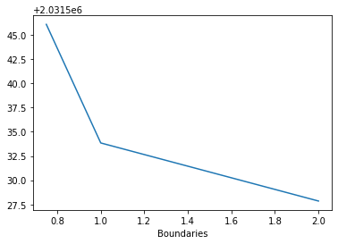

```python
obj_list =[]

bound = [0.75,1,1.5,1.75,2]
for i in bound:

    from pyomo.environ import *
    opt = SolverFactory('glpk')

    model = ConcreteModel(name="Vaccine Model")
    #Sets#
    # Vaccine Storage Units
    model.F = Set(initialize=F)
    # Vaccine Centers
    model.D = Set(initialize=D)
    # Vaccine Types
    model.V = Set(initialize=V)
    # decision variables
    model.X = Var(model.V,model.F,model.D, domain= NonNegativeReals)
    model.Y = Var(model.F,model.D ,domain= NonNegativeReals,bounds=(0,i))

    # Minimize the cost
    def cost_rule(model):
        return sum(sum(sum(extracost[v-1]*model.X[v,f,d] for d in model.D) for f in model.F) for v in model.V)+\
    sum(sum(Tc*dist[f-1,d-1]*model.Y[f,d] for d in model.V) for f in model.F)+\
    sum(sum(sum(Hc_VSU[f-1]*(stock[v-1,f-1] - model.X[v,f,d]) for d in model.D) for v in model.V) for f in model.F)+\
    sum(sum(sum(Hc_VC[d-1]*(model.X[v,f,d] - demand[v-1,d-1]) for f in model.F) for v in model.V) for d in model.D)+\
    sum(sum(risk[d-1]*model.Y[f,d] for f in model.F) for d in model.D)
    model.Obj = Objective(rule=cost_rule, sense=minimize)


    #Constraints
    def flow(model,v,f):
        return sum(model.X[v,f,d] for d in model.D) >= stock[v-1,f-1]*0.80 #at least 5 vials from each storage..
    model.flow_const = Constraint(model.V,model.F, rule=flow)

    def stock_flow_limit(model, v,f):
        return stock[v-1,f-1]-sum(model.X[v,f,d] for d in model.D) >= 2
    model.stock_const = Constraint(model.V,model.F, rule=stock_flow_limit)

    def storage_output(model,v, f):
        return stock[v-1,f-1] - sum(model.X[v,f,d] for d in model.D) <= storage_cap[v-1,f-1]
    model.storage_const = Constraint(model.V,model.F, rule=storage_output)

    def vc_demand(model,v,d):
        return sum(model.X[v,f,d] for f in model.F) >= demand[v-1,d-1]
    model.demand_const = Constraint(model.V, model.D, rule=vc_demand)

    def vc_capacity(model,v,d):
        return sum(model.X[v,f,d] for f in model.F) <= cap[v-1,d-1]
    model.cap_const = Constraint(model.V, model.D, rule=vc_capacity)

    ## BINARY CONSTRAINTS ##

    # each VSU should transfer vaccines to at least 2 VCs.
    def travel_VSU(model,f):
        return sum(model.Y[f,d] for d in model.D) >= 2
    model.travel_VSU_const = Constraint(model.F, rule=travel_VSU)

    # each VC should receive vaccines from at least 2 VCUs.
    def travel_VC(model,d):
        return sum(model.Y[f,d] for f in model.F) >= 2
    model.travel_VC_const = Constraint(model.D, rule=travel_VC)

    #solve
    results = opt.solve(model)

    OBJ = model.Obj()
    Y_values = model.Y.display()

    obj_list = np.append(obj_list, OBJ)

print(obj_list)

import matplotlib.pyplot as plt
%matplotlib inline
plt.plot(bound,obj_list)
plt.xlabel('Boundaries')
```

## Comparison and Interpratation of the solutions for both integer and relaxed problems

After relaxing the integer problem, the objective function result has been changed according to the upper boundary. For 1, the OF has't changed, however, after simulating with different bounds, it can be seen on the above graph that while the boundaries are relaxed more, the total cost decreases, because the problem has been relaxed.

# f) Solving several instances with different numbers of variables using randomly generated data.

In this step, the integer problem was solved with several instances. In order to do that i value was iterated in range(2,20). Finally, the execution times were printed and plotted.

```python
# libraries
import numpy as np
import random
from pyomo.environ import *
import time


# defining empty list for the execution times.
time_list = []

for i in range(2,20):

    random.seed(i)

    F =  list(range(1,i));
    D =  list(range(1,i*2));
    V =  list(range(1,i+2));

    Tc = 5;


    dist = np.random.uniform(5,40,([len(F),len(D)]));

    extracost = np.random.uniform(2.25,10,len(V));

    Hc_VSU = np.random.uniform(2,9,len(F));

    Hc_VC = np.random.uniform(2,9,len(D));

    stock = np.random.randint(2500,3500,size = (len(V),len(F)));


    #Storage capacity is determined by number of required diffrenet type freezers.
    ## *100 for each vials
    storage_cap = np.random.randint(2000,5500,size = (len(V),len(F)));

    demand = np.random.randint(350,2200,size = (len(V),len(D)));

    cap = np.random.randint(2000,4000,size = (len(V),len(D)));

    ## NEW PARAMETER!! ##

    #risk factor to prioritize the destination
    risk = np.random.randint(1,9,len(D));

    ###MODEL

    opt = SolverFactory('glpk')

    model = ConcreteModel(name="Vaccine Model")

    #Sets#
    # Factories
    model.F = Set(initialize=F)
    # Vaccine Centers
    model.D = Set(initialize=D)
    # Vaccine Types
    model.V = Set(initialize=V)


    # decision variables
    model.X = Var(model.V,model.F,model.D, domain= NonNegativeIntegers)
    model.Y = Var(model.F,model.D ,domain= Binary)

    # Minimize the cost
    def cost_rule(model):
        return sum(sum(sum(extracost[v-1]*model.X[v,f,d] for d in model.D) for f in model.F) for v in model.V)+\
    sum(sum(Tc*dist[f-1,d-1]*model.Y[f,d] for d in model.V) for f in model.F)+\
    sum(sum(sum(Hc_VSU[f-1]*(stock[v-1,f-1] - model.X[v,f,d]) for d in model.D) for v in model.V) for f in model.F)+\
    sum(sum(sum(Hc_VC[d-1]*(model.X[v,f,d] - demand[v-1,d-1]) for f in model.F) for v in model.V) for d in model.D)+\
    sum(sum(risk[d-1]*model.Y[f,d] for f in model.F) for d in model.D)
    model.Obj = Objective(rule=cost_rule, sense=minimize)

    #Constraints

    def flow(model,v,f):
        return sum(model.X[v,f,d] for d in model.D) >= stock[v-1,f-1]*0.80 #at least 5 vials from each storage..
    model.flow_const = Constraint(model.V,model.F, rule=flow)

    def stock_flow_limit(model, v,f):
        return stock[v-1,f-1]-sum(model.X[v,f,d] for d in model.D) >= 2
    model.stock_const = Constraint(model.V,model.F, rule=stock_flow_limit)

    def storage_output(model,v, f):
        return stock[v-1,f-1] - sum(model.X[v,f,d] for d in model.D) <= storage_cap[v-1,f-1]
    model.storage_const = Constraint(model.V,model.F, rule=storage_output)

    def vc_demand(model,v,d):
        return sum(model.X[v,f,d] for f in model.F) >= demand[v-1,d-1]
    model.demand_const = Constraint(model.V, model.D, rule=vc_demand)

    def vc_capacity(model,v,d):
        return sum(model.X[v,f,d] for f in model.F) <= cap[v-1,d-1]
    model.cap_const = Constraint(model.V, model.D, rule=vc_capacity)

    ## BINARY CONSTRAINTS ##

    # each VSU should transfer vaccines to at least 2 VCs.
    def travel_VSU(model,f):
        return sum(model.Y[f,d] for d in model.D) >= 2
    model.travel_VSU_const = Constraint(model.F, rule=travel_VSU)

    # each VC should receive vaccines from at least 2 VCUs.
    def travel_VC(model,d):
        return sum(model.Y[f,d] for f in model.F) >= 1
    model.travel_VC_const = Constraint(model.D, rule=travel_VC)

    start = time.time()
    #solve
    results = opt.solve(model)
    end = time.time()
    execution = end-start
    #num_variables = len(V)*len(F)*len(D)
    time_list = np.append(time_list,execution)

print(time_list)
```

```
[0.18177605 0.18275094 0.16476321 0.20637703 0.20563102 0.2142086
 0.26167941 0.27771783 0.29543424 0.32596874 0.34967327 0.411623
 0.4810307  0.4836669  0.57741785 0.63670254 1.07809114 1.25341797]
```

## Interprating the execution times

During iteration, first, the model has been run with less decision variables and then nnumber of variables has been increaed slightly. Moreover, when increasing the instances' size, the execution time went up as well.

# g) Several Instances with the same data

For the integer problem in d), solve several instances with the same data, using (10 to 20) different values for one of the parameters in the model (choose a parameter you think may provide insights for the interpretation of the different solution values). Collect the resulting optimal values of the objective function, print and plot them. Comment on these values.

```python
import numpy as np


m =  5 #list(range(1,6));
n =  13 #list(range(1,14));
e =  3 #list(range(1,4));

Tc = 5;

a=2;
b=1;

dist = np.array([[3.29 ,3.32 ,3.13 ,3.16 ,3.14 ,3.58 ,5.58  ,8.72 , 9.13 , 3.95 ,7.79 ,7.11 ,4.27   ]  ,
                [4.13 ,5.69 ,8.67 ,7.9  ,7.71 ,5.47 ,5.72  ,6.32 , 4.28 , 8.31 ,9.55 ,3.25 ,1.44    ] ,
                [2.49 ,6.80 ,2.76 ,8.59 ,4.72 ,2.38 ,7.50  ,4.34 , 7.19 , 5.36 ,5.16 ,8.37 ,8.81    ] ,
                [6.36 ,4.65 ,8.22 ,7.16 ,8.55 ,2.47 ,7.69  ,2.45 , 6.77 , 1.03 ,5.33 ,1.31 ,6.25    ] ,
                [3.21 ,3.43 ,6.13 ,2.39 ,8.74 ,6.68 ,4.00  ,4.19 , 8.95 , 7.29 ,6.16 ,4.93 ,8.33    ] ]);

extracost = np.array([ 6.5,4.75,2.25 ]);


Hc_VSU = np.array([7.0, 5.0, 7.5, 7.0, 4.0]);


Hc_VC = np.array([3.5,8.0,9.7,6.5,4.5,5.0,9.0,8.0,7.2,8.4,4.2,3.6,9.5]);


stock = np.array([[1850 ,2450 ,1735 ,2500 ,1400],
                  [1600 ,2400 ,1200 ,2100 ,3500],
                  [4000 ,3800 ,2800 ,4100 ,3800]]);


#Storage capacity is determined by number of required diffrenet type freezers.
## *100 for each vials
storage_cap = np.array([[1700, 4500, 2200, 3100, 1100],
                       [2700, 2100, 1800, 2000, 3800],
                       [4700, 4100, 2100, 4200, 3800]]);

demand =np.array([[1100 ,750  ,375  ,580  ,950  ,970  ,440  ,745  ,465  ,630  ,920  ,1260 ,730 ],
                  [960  ,885  ,505  ,1040 ,920  ,720  ,460  ,1100 ,830  ,820  ,495  ,970  ,960 ],
                  [2430 ,1500 ,990  ,870  ,1140 ,2060 ,1010 ,1620 ,1390 ,910  ,420  ,1890 ,510 ]]);



cap = np.array([[1400 ,800  ,500  ,600  ,955   ,975  ,445  ,750  ,475 ,635 ,930  ,1300 ,740],
                [1000 ,890  ,510  ,1050  ,950   ,750  ,500  ,1105 ,840 ,830 ,500  ,980  ,980],
                [2600 ,1700 ,1200 ,950  ,1400  ,2400 ,1200 ,2000 ,1800,1300,800  ,2400 ,600]]);

## NEW PARAMETER!! ##

#risk factor to prioritize the destination - less values are more important, because of using it in the minimization.
risk = np.array([1,3,6,5,1,2,5,1,7,4,5,8,2]);
```

```python
###MODEL

from pyomo.environ import *
opt = SolverFactory('glpk')

def corona_model(m,n,e,dist,extracost,Hc_VSU,Hc_VC,stock,storage_cap,demand,cap):

    model = ConcreteModel(name="Vaccine Model")

    #Sets#
    # VSUs
    model.F = RangeSet(1,m)
    # Vaccine Centers
    model.D = RangeSet(1,n)
    # Vaccine Types
    model.V = RangeSet(1,e)

    # decision variables
    model.X = Var(model.V,model.F,model.D, domain= NonNegativeIntegers)
    model.Y = Var(model.F,model.D ,domain= Binary)

    # Minimize the cost
    def cost_rule(model):
        return sum(sum(sum(extracost[v-1]*model.X[v,f,d] for d in model.D) for f in model.F) for v in model.V)+\
                sum(sum(Tc*dist[f-1,d-1]*model.Y[f,d] for d in model.V) for f in model.F)+\
                sum(sum(sum(Hc_VSU[f-1]*(stock[v-1,f-1] - model.X[v,f,d]) for d in model.D) for v in model.V) for f in model.F)+\
                sum(sum(sum(Hc_VC[d-1]*(model.X[v,f,d] - demand[v-1,d-1]) for f in model.F) for v in model.V) for d in model.D)+\
                sum(sum(risk[d-1]*model.Y[f,d] for f in model.F) for d in model.D)
    model.Obj = Objective(rule=cost_rule, sense=minimize)

    #Constraints
    def flow(model,v,f):
        return sum(model.X[v,f,d] for d in model.D) >= stock[v-1,f-1]*0.80
    model.flow_const = Constraint(model.V,model.F, rule=flow)

    def stock_flow_limit(model, v,f):
        return stock[v-1,f-1]-sum(model.X[v,f,d] for d in model.D) >= 2
    model.stock_const = Constraint(model.V,model.F, rule=stock_flow_limit)

    def storage_output(model,v, f):
        return stock[v-1,f-1] - sum(model.X[v,f,d] for d in model.D) <= storage_cap[v-1,f-1]
    model.storage_const = Constraint(model.V,model.F, rule=storage_output)

    def vc_demand(model,v,d):
        return sum(model.X[v,f,d] for f in model.F) >= demand[v-1,d-1]
    model.demand_const = Constraint(model.V, model.D, rule=vc_demand)

    def vc_capacity(model,v,d):
        return sum(model.X[v,f,d] for f in model.F) <= cap[v-1,d-1]
    model.cap_const = Constraint(model.V, model.D, rule=vc_capacity)

    ## BINARY CONSTRAINTS ##

    # each VSU should transfer vaccines to at least 2 VCs.
    def travel_VSU(model,f):
        return sum(model.Y[f,d] for d in model.D) >= a
    model.travel_VSU_const = Constraint(model.F, rule=travel_VSU)

    # each VC should receive vaccines from at least 1 VCUs.
    def travel_VC(model,d):
        return sum(model.Y[f,d] for f in model.F) >= b
    model.travel_VC_const = Constraint(model.D, rule=travel_VC)

    #solve
    results = opt.solve(model)


    return model.Obj()
```

```python
corona_model(m,n,e,dist,extracost,Hc_VSU,Hc_VC,stock,storage_cap,demand,cap)
```

```
2031435.0
```

## 1) Changing the Limit of Travels between VSUs and VCs

- In this part, the OF observed by giving different values to the RHS of the constraint Travel_VSU. (each VSU should transfer vaccines to at least "2" VCs.) Here, the "2" value is replacing by 0,1,2,3,4 and 5, respectively.
- It is clear that between 0 and 2, the total cost does not change. However, when the parameter is increased to more than 2, the total cost starts to increase.

```
[2031435. 2031435. 2031435. 2031437. 2031442. 2031451.]
```

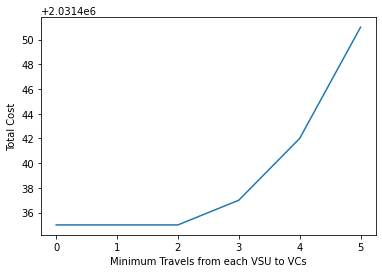

```python
import matplotlib.pyplot as plt
%matplotlib inline

travel_VCU=np.array([0,1,2,3,4,5])
dim =travel_VCU.size
all_obj=np.zeros(dim)

for cont in range(0,dim):
    a=travel_VCU[cont] #each time increasing.
    Obj=corona_model(m,n,e,dist,extracost,Hc_VSU,Hc_VC,stock,storage_cap,demand,cap)
    all_obj[cont]=Obj
print(all_obj)
plt.plot(travel_VCU,all_obj)
plt.xlabel('Minimum Travels from each VSU to VCs')
plt.ylabel('Total Cost')
plt.figure()
```

- In this part, the OF observed by giving different values to the RHS of the constraint Travel_VC. (each VC should receive vaccines from at least "1" VCs.) Here, the "1" value is replacing by 0,1,2,3,4 and 5, respectively.
- It is clear that if RHS value in the constraint increases, the total cost is increasing as well.

```
[2031392.15 2031451.   2031533.85 2031654.2  2031794.4  2031953.55]
```

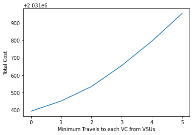

```python
import matplotlib.pyplot as plt
%matplotlib inline

travel_VC=np.array([0,1,2,3,4,5])
dim =travel_VC.size
all_obj=np.zeros(dim)

for cont in range(0,dim):
    b=travel_VC[cont] #each time increasing.
    Obj=corona_model(m,n,e,dist,extracost,Hc_VSU,Hc_VC,stock,storage_cap,demand,cap)
    all_obj[cont]=Obj
print(all_obj)
plt.plot(travel_VC,all_obj)
plt.xlabel('Minimum Travels to each VC from VSUs')
plt.ylabel('Total Cost')
plt.figure()
```

## 2) Changing the Demand Parameter at VC

- In this part, the OF observed by giving different values to the RHS of the constraint Demand Constraint at VCs. The parameters ranges between 900 and 1110 with 10 increasement.
- It is clear that if RHS value in the constraint increases, the total cost is decreasing.

```
[2034253.55 2034138.55 2034023.55 2033908.55 2033793.55 2033678.55
 2033563.55 2033448.55 2033333.55 2033218.55 2033103.55 2032988.55
 2032873.55 2032758.55 2032643.55 2032528.55 2032413.55 2032298.55
 2032183.55 2032068.55 2031953.55]
```

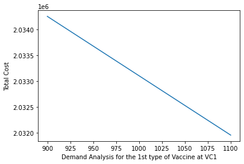

```python
import matplotlib.pyplot as plt
%matplotlib inline

v_demand=np.arange(900,1110,10)
dim =v_demand.size
all_obj=np.zeros(dim)

for cont in range(0,dim):
    demand[0,0]=v_demand[cont] #each time increasing.
    Obj=corona_model(m,n,e,dist,extracost,Hc_VSU,Hc_VC,stock,storage_cap,demand,cap)
    all_obj[cont]=Obj
print(all_obj)
plt.plot(v_demand,all_obj)
plt.xlabel('Demand Analysis for the 1st type of Vaccine at VC1')
plt.ylabel('Total Cost')
plt.figure()
```

## 3) Changing the Stock Parameter at VSU

- In this part, the OF observed by giving different values to the RHS of the constraint Stock Constraint at VSUs. The parameters ranges between 1840 and 1900 with 1 unit increasement.
- It is clear that if RHS value in the constraint increases, the total cost is increasing as well.

```
[2031073.55 2031161.55 2031249.55 2031337.55 2031425.55 2031513.55
 2031601.55 2031689.55 2031777.55 2031865.55 2031953.55 2032041.55
 2032129.55 2032217.55 2032305.55 2032393.55 2032481.55 2032569.55
 2032657.55 2032745.55 2032833.55 2032921.55 2033009.55 2033097.55
 2033185.55 2033273.55 2033361.55 2033449.55 2033537.55 2033625.55
 2033713.55 2033801.55 2033889.55 2033977.55 2034065.55 2034153.55
 2034241.55 2034329.55 2034417.55 2034505.55 2034593.55 2034681.55
 2034769.55 2034857.55 2034945.55 2035033.55 2035121.55 2035209.55
 2035297.55 2035385.55 2035473.55 2035561.55 2035649.55 2035737.55
 2035825.55 2035913.55 2036001.55 2036089.55 2036177.55 2036265.55]
```

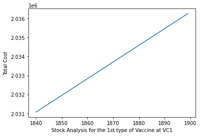

```python
import matplotlib.pyplot as plt
%matplotlib inline

v_stock=np.arange(1840,1900,1)
dim =v_stock.size
all_obj=np.zeros(dim)

for cont in range(0,dim):
    stock[0,0]=v_stock[cont] #each time increasing.
    Obj=corona_model(m,n,e,dist,extracost,Hc_VSU,Hc_VC,stock,storage_cap,demand,cap)
    all_obj[cont]=Obj
print(all_obj)
plt.plot(v_stock,all_obj)
plt.xlabel('Stock Analysis for the 1st type of Vaccine at VC1')
plt.ylabel('Total Cost')
plt.figure()
```

```
[2036265.55 2036265.55 2036265.55 2036265.55 2036265.55 2036265.55
 2036265.55 2036265.55 2036265.55 2036265.55 2036265.55 2036265.55
 2036265.55 2036265.55 2036265.55 2036265.55 2036265.55 2036265.55
 2036265.55 2036265.55 2036265.55 2036265.55 2036265.55 2036265.55
 2036265.55 2036265.55 2036265.55 2036265.55 2036265.55 2036265.55
 2036265.55 2036265.55 2036265.55 2036265.55 2036265.55 2036265.55
 2036265.55 2036265.55 2036265.55 2036265.55 2036265.55 2036265.55
 2036265.55 2036265.55 2036265.55 2036265.55 2036265.55 2036265.55
 2036265.55 2036265.55 2036265.55 2036265.55 2036265.55 2036265.55
 2036265.55 2036265.55 2036265.55 2036265.55 2036265.55 2036265.55
 2036265.55 2036265.55 2036265.55 2036265.55 2036265.55 2036265.55
 2036265.55 2036265.55 2036265.55 2036265.55 2036265.55 2036265.55
 2036265.55 2036265.55 2036265.55 2036265.55 2036265.55 2036265.55
 2036265.55 2036265.55]
```

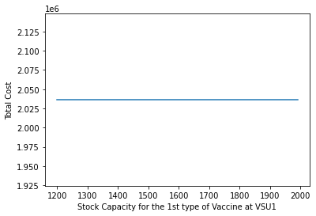

```python
import matplotlib.pyplot as plt
%matplotlib inline

v_stock=np.arange(1200,2000,10)
dim =v_stock.size
all_obj=np.zeros(dim)

for cont in range(0,dim):
    cap[0,0]=v_stock[cont] #each time increasing.
    Obj=corona_model(m,n,e,dist,extracost,Hc_VSU,Hc_VC,stock,storage_cap,demand,cap)
    all_obj[cont]=Obj
print(all_obj)
plt.plot(v_stock,all_obj)
plt.xlabel('Stock Capacity for the 1st type of Vaccine at VSU1')
plt.ylabel('Total Cost')
plt.figure()
```